# Overlap Results

# Descriptives

## Number of overall effects:

```r
overlap_data %>%
  count()
```

```
## # A tibble: 1 x 1
##       n
##   <int>
## 1    53
```

## Effects per comparison group:

```r
overlap_data %>%
  group_by(pt_comparison) %>%
  count()
```

```
## # A tibble: 2 x 2
## # Groups:   pt_comparison [2]
##   pt_comparison      n
##   <fct>          <int>
## 1 pt_v_objective    31
## 2 pt_v_control      22
```

## Number of unique samples

```r
overlap_data %>%
  dplyr::select(sample_number_total) %>%
  unique() %>%
  count()
```

```
## # A tibble: 1 x 1
##       n
##   <int>
## 1    32
```

## Average sample size per cell

**To be used in power analysis**

```r
overlap_data %>%
  dplyr::select(n_pt, n_comparison) %>%
  unique() %>%
  summarise(mean(n_pt),
            mean(n_comparison))
```

```
## # A tibble: 1 x 2
##   `mean(n_pt)` `mean(n_comparison)`
##          <dbl>                <dbl>
## 1         64.6                 64.2
```

# Meta-analysis results for Overlap outcome

## Model Results

*Note: this comparison is the same as in the overall model interacting with outcome types, as the small k per cell in the overlap/merging category was the reason we had to collapse cross other perspective taking comparisons in that overall model.*

### Contrasts

```r
contrasts(overlap_data$pt_comparison)
```

```
##                pt_v_control
## pt_v_objective            0
## pt_v_control              1
```

### Model nesting outcomes within sample crossed with scale type

```r
overlap_data$outcome_scale_group <- droplevels(overlap_data$outcome_scale_group)
#levels(overlap_data$outcome_scale_group)

overlap_pt <- rma.mv(dunb,
                      var_dunb,
                      mods = ~ pt_comparison,
                      random = list(~ 1 | sample_number_total/outcomes_within_sample_var,
                                    ~ 1 | outcome_scale_group), data = overlap_data)

overlap_pt
```

```
##
## Multivariate Meta-Analysis Model (k = 53; method: REML)
##
## Variance Components:
##
##             estim    sqrt  nlvls  fixed
## sigma^2.1  0.1918  0.4379     32     no
## sigma^2.2  0.0169  0.1300     38     no
## sigma^2.3  0.0618  0.2486      3     no
##                                                    factor
## sigma^2.1                             sample_number_total
## sigma^2.2  sample_number_total/outcomes_within_sample_var
## sigma^2.3                             outcome_scale_group
##
## Test for Residual Heterogeneity:
## QE(df = 51) = 307.2560, p-val < .0001
##
## Test of Moderators (coefficient 2):
## QM(df = 1) = 0.7615, p-val = 0.3828
##
## Model Results:
##
##                            estimate      se     zval    pval    ci.lb   ci.ub
## intrcpt                      0.3215  0.1819   1.7671  0.0772  -0.0351  0.6780
## pt_comparisonpt_v_control   -0.0690  0.0791  -0.8727  0.3828  -0.2240  0.0860
##
## intrcpt                    .
## pt_comparisonpt_v_control
##
## ---
## Signif. codes:  0 '***' 0.001 '**' 0.01 '*' 0.05 '.' 0.1 ' ' 1
```

The intercept is marginally different from zero. The pt v control condition does not differ significantly from the intercept.

### Model adding paper as nesting factor

```r
overlap_pt_auth <- rma.mv(dunb,
                      var_dunb,
                      mods = ~ pt_comparison,
                      random = list(~ 1 | authors/sample_number_total/outcomes_within_sample_var,
                                    ~ 1 | outcome_scale_group),
                      data = overlap_data)

overlap_pt_auth
```

```
##
## Multivariate Meta-Analysis Model (k = 53; method: REML)
##
## Variance Components:
##
##             estim    sqrt  nlvls  fixed
## sigma^2.1  0.1983  0.4453     21     no
## sigma^2.2  0.0167  0.1291     32     no
## sigma^2.3  0.0031  0.0557     38     no
## sigma^2.4  0.0992  0.3150      3     no
##                                                            factor
## sigma^2.1                                                 authors
## sigma^2.2                             authors/sample_number_total
## sigma^2.3  authors/sample_number_total/outcomes_within_sample_var
## sigma^2.4                                     outcome_scale_group
##
## Test for Residual Heterogeneity:
## QE(df = 51) = 307.2560, p-val < .0001
##
## Test of Moderators (coefficient 2):
## QM(df = 1) = 0.1384, p-val = 0.7099
##
## Model Results:
##
##                            estimate      se     zval    pval    ci.lb   ci.ub
## intrcpt                      0.2437  0.2215   1.1000  0.2713  -0.1905  0.6779
## pt_comparisonpt_v_control   -0.0290  0.0779  -0.3720  0.7099  -0.1816  0.1237
##
## intrcpt
## pt_comparisonpt_v_control
##
## ---
## Signif. codes:  0 '***' 0.001 '**' 0.01 '*' 0.05 '.' 0.1 ' ' 1
```

The intercept is no longer marginally different from zero when we account for variance due to paper.

## Checking if model is overparemetized

**Doing this for model with author as it has the extra nesting parameter.**

```r
# Checking if model is over-parametized
par(mfrow=c(2,2))
profile(overlap_pt_auth)
```

```
## Profiling sigma2 = 1
##
```

```
## Profiling sigma2 = 2
##
```

```
## Profiling sigma2 = 3
##
```

```
## Profiling sigma2 = 4
##
```

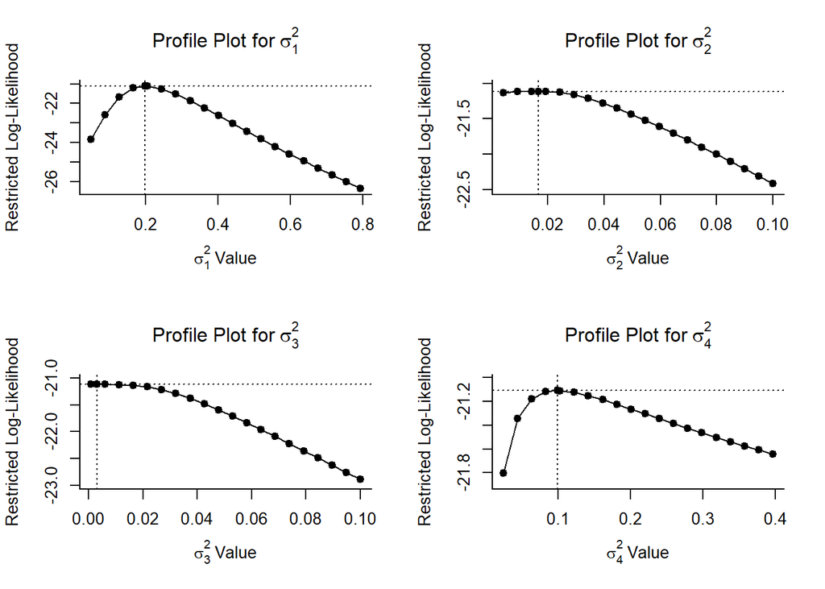

```r
#Looks fine
```

Looks good! No gaps or excessively flat areas

## Marginal main effects

### Withouut paper

```r
qdrq_overlap <- qdrg(object = overlap_pt, data = overlap_data)

emmeans_overlap <- summary(emmeans(qdrq_overlap, "pt_comparison"))
emmeans_overlap
```

```
##  pt_comparison  emmean    SE  df asymp.LCL asymp.UCL
##  pt_v_objective  0.321 0.182 Inf   -0.0351     0.678
##  pt_v_control    0.252 0.182 Inf   -0.1043     0.609
##
## Confidence level used: 0.95
```

This comparison is the same as the overall model. Without the interaction, the values change slightly, but the pattern and significance do not.

### With paper

```r
qdrq_overlap_auth <- qdrg(object = overlap_pt_auth, data = overlap_data)

emmeans_overlap_auth <- summary(emmeans(qdrq_overlap_auth, "pt_comparison"))
emmeans_overlap_auth
```

```
##  pt_comparison  emmean    SE  df asymp.LCL asymp.UCL
##  pt_v_objective  0.244 0.222 Inf    -0.191     0.678
##  pt_v_control    0.215 0.221 Inf    -0.218     0.648
##
## Confidence level used: 0.95
```

Lower parameters than without paper, but still not significantly diff from 0.

## Heterogeneity

### I2 overall model

#### Without paper

```r
get_I2_overall(overlap_data, overlap_pt)
```

```
## [1] 87.82242
```

This heterogeneity is still high, but lower than with the stereotyping outcome or the overall model with perspective taking interacting with outcome type.

#### With paper

```r
get_I2_overall(overlap_data, overlap_pt_auth)
```

```
## [1] 89.42855
```

### I2 for levels of variance

*Left value corresponds to top sigma in Variance components output in model results (Sample_number_total). Right-most value corresponds to bottom sigma (Outcome_scale group).*

#### Without paper

```r
get_I2_levels(overlap_pt)
```

```
## [1] 62.38  5.50 20.10
```

Most of the heterogeneity is due to between-studies variance. However, a large amount is also due to scales of measurement in the crossed structure.

#### With paper

```r
get_I2_levels(overlap_pt_auth)
```

```
## [1] 55.98  4.71  0.88 28.00
```

When we add in paper, we see that most of the between-studies variance is actually due to paper, not sample. This seems problematic.

## Post-hoc power

```r
subgroup_power(n_groups = 2,
               effect_sizes = c(.24, .22),
               sample_size = 132,
               k = 48,
               es_type = "d")
```

```
##
##  Power Analysis for Subgroup analysis:
##
##  Number of Groups:                  2
##  Groups:
##  Expected Effect Sizes:             0.24 0.22
##  Expected Sample Size (per group):  66
##  Expected Number of Studies:        48
##
##  Esimated Power to detect subgroup differences
##
##  Fixed-Effects Model:                  0.06821292
##  Random-Effects Model (i2 = 0%):       0.06821292
##  Random-Effects Model (i2 = 25%):      0.06362586
##  Random-Effects Model (i2 = 50%):      0.0590607
##  Random-Effects Model (i2 = 75%):      0.05451842
```

Impossible to find a difference, but that is basically because there isn’t one…

## Forest Plot

**For final model including author**

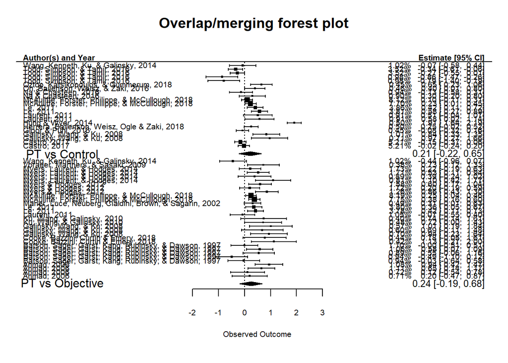

```r
par(mfrow=c(1,1))
forest(overlap_pt_auth,
       slab = paste(overlap_data$authors,
                    overlap_data$Year, sep = ", "),
       header="Author(s) and Year",
       showweights=TRUE,
       main = "Overlap/merging forest plot",
       ylim = c(-2, 57),
       order = order(overlap_data$pt_comparison),
       rows = c(-1:29, 33:54),
       addfit=FALSE,
       cex=0.65)

text(x=-7, y=31, labels=c("PT vs Control"))
text(x=-7, y=-3, labels=c("PT vs Objective"))

addpoly(x = 0.244,
        sei = 0.222,
        ci.lb = -0.191,
        ci.ub = 0.678,
        rows = -3,
        cex = .8)

addpoly(x = 0.215,
        sei = 0.221,
        ci.lb = -0.218,
        ci.ub = 0.648,
        rows = 31,
        cex = .8)
```

# Moderator Analyses

## Scale of measurement

```r
overlap_data %>%
  group_by(outcome_scale_group) %>%
  count()
```

```
## # A tibble: 3 x 2
## # Groups:   outcome_scale_group [3]
##   outcome_scale_group     n
##   <fct>               <int>
## 1 7                      32
## 2 8                      16
## 3 9                       5
```

```r
overlap_model_mod1 <- rma.mv(dunb,
                      var_dunb,
                      mods = ~ pt_comparison*outcome_scale_group,
                      random = list(~ 1 | authors/sample_number_total/outcomes_within_sample_var),
                      data = overlap_data)

overlap_model_mod1
```

```
##
## Multivariate Meta-Analysis Model (k = 53; method: REML)
##
## Variance Components:
##
##             estim    sqrt  nlvls  fixed
## sigma^2.1  0.2064  0.4543     21     no
## sigma^2.2  0.0229  0.1513     32     no
## sigma^2.3  0.0017  0.0416     38     no
##                                                            factor
## sigma^2.1                                                 authors
## sigma^2.2                             authors/sample_number_total
## sigma^2.3  authors/sample_number_total/outcomes_within_sample_var
##
## Test for Residual Heterogeneity:
## QE(df = 47) = 259.4843, p-val < .0001
##
## Test of Moderators (coefficients 2:6):
## QM(df = 5) = 14.9851, p-val = 0.0104
##
## Model Results:
##
##                                                 estimate      se     zval
## intrcpt                                           0.5873  0.1265   4.6415
## pt_comparisonpt_v_control                        -0.0446  0.0827  -0.5386
## outcome_scale_group8                             -0.4736  0.1643  -2.8826
## outcome_scale_group9                             -0.7621  0.2881  -2.6457
## pt_comparisonpt_v_control:outcome_scale_group8   -0.0125  0.2912  -0.0431
## pt_comparisonpt_v_control:outcome_scale_group9    0.2871  0.3245   0.8847
##                                                   pval    ci.lb    ci.ub
## intrcpt                                         <.0001   0.3393   0.8353  ***
## pt_comparisonpt_v_control                       0.5901  -0.2068   0.1176
## outcome_scale_group8                            0.0039  -0.7957  -0.1516   **
## outcome_scale_group9                            0.0082  -1.3267  -0.1975   **
## pt_comparisonpt_v_control:outcome_scale_group8  0.9656  -0.5832   0.5581
## pt_comparisonpt_v_control:outcome_scale_group9  0.3763  -0.3490   0.9232
##
## ---
## Signif. codes:  0 '***' 0.001 '**' 0.01 '*' 0.05 '.' 0.1 ' ' 1
```

Scale 7 (Self-report IOS merging/scales) while in the pt vs objective comparison is the reference group. These are simple effects in which the effect sizes become significantly lower for the pt vs objective comparison when merging is measured from overlap of traits/attributes or measures of social distancing. There are no interactions.

### Marginal main effects

```r
qdrq_overlap2 <- qdrg(object = overlap_model_mod1, data = overlap_data)

emmeans_overlap2 <- summary(emmeans(qdrq_overlap2, "pt_comparison", "outcome_scale_group"))
emmeans_overlap2
```

```
## outcome_scale_group = 7:
##  pt_comparison   emmean    SE  df asymp.LCL asymp.UCL
##  pt_v_objective  0.5873 0.127 Inf     0.339     0.835
##  pt_v_control    0.5428 0.129 Inf     0.289     0.797
##
## outcome_scale_group = 8:
##  pt_comparison   emmean    SE  df asymp.LCL asymp.UCL
##  pt_v_objective  0.1137 0.178 Inf    -0.235     0.463
##  pt_v_control    0.0566 0.285 Inf    -0.502     0.615
##
## outcome_scale_group = 9:
##  pt_comparison   emmean    SE  df asymp.LCL asymp.UCL
##  pt_v_objective -0.1748 0.287 Inf    -0.736     0.387
##  pt_v_control    0.0678 0.321 Inf    -0.561     0.696
##
## Confidence level used: 0.95
```

When using a self-reported merging scale both pt vs objective and control lead to medium to large effect sizes that differed from 0. When using both the attribution and social distance scales, neither comparison significantly differed from 0.

### Heterogeneity

#### I2 overall

```r
get_I2_overall(overlap_data, overlap_model_mod1)
```

```
## [1] 85.76727
```

With this moderator, the heterogeneity lessens a bit.

#### I2 for levels of variance

*Left value corresponds to top sigma in Variance components output in model results (Sample_number_total). Right-most value corresponds to bottom sigma (Outcome_scale group).*

```r
get_I2_var_levels(overlap_data, overlap_model_mod1)
```

```
## [1] 76.62  8.50  0.64
```

## Target - amount of information

```r
overlap_model_mod2 <- rma.mv(dunb,
                      var_dunb,
                      mods = ~ pt_comparison*target_information,
                      random = list(~ 1 | authors/sample_number_total/outcomes_within_sample_var,
                                    ~ 1 | outcome_scale_group),
                      data = overlap_data)

overlap_model_mod2
```

```
##
## Multivariate Meta-Analysis Model (k = 53; method: REML)
##
## Variance Components:
##
##             estim    sqrt  nlvls  fixed
## sigma^2.1  0.1490  0.3860     21     no
## sigma^2.2  0.0191  0.1382     32     no
## sigma^2.3  0.0078  0.0881     38     no
## sigma^2.4  0.0863  0.2938      3     no
##                                                            factor
## sigma^2.1                                                 authors
## sigma^2.2                             authors/sample_number_total
## sigma^2.3  authors/sample_number_total/outcomes_within_sample_var
## sigma^2.4                                     outcome_scale_group
##
## Test for Residual Heterogeneity:
## QE(df = 47) = 177.2239, p-val < .0001
##
## Test of Moderators (coefficients 2:6):
## QM(df = 5) = 6.9915, p-val = 0.2213
##
## Model Results:
##
##                                                estimate      se     zval
## intrcpt                                          0.2760  0.3097   0.8914
## pt_comparisonpt_v_control                        0.0223  0.2590   0.0862
## target_information2                             -0.0703  0.3172  -0.2216
## target_information3                             -0.0133  0.2817  -0.0472
## pt_comparisonpt_v_control:target_information2   -0.1905  0.2804  -0.6792
## pt_comparisonpt_v_control:target_information3    0.1978  0.2918   0.6780
##                                                  pval    ci.lb   ci.ub
## intrcpt                                        0.3727  -0.3309  0.8830
## pt_comparisonpt_v_control                      0.9313  -0.4852  0.5299
## target_information2                            0.8246  -0.6920  0.5514
## target_information3                            0.9624  -0.5655  0.5389
## pt_comparisonpt_v_control:target_information2  0.4970  -0.7401  0.3592
## pt_comparisonpt_v_control:target_information3  0.4978  -0.3740  0.7696
##
## ---
## Signif. codes:  0 '***' 0.001 '**' 0.01 '*' 0.05 '.' 0.1 ' ' 1
```

None are significant. I2 lowered.

### Marginal main effects

```r
qdrq_overlap3 <- qdrg(object = overlap_model_mod2, data = overlap_data)

emmeans_overlap3 <- summary(emmeans(qdrq_overlap3, "pt_comparison", "target_information"))
emmeans_overlap3
```

```
## target_information = 1:
##  pt_comparison  emmean    SE  df asymp.LCL asymp.UCL
##  pt_v_objective 0.2760 0.310 Inf  -0.33092     0.883
##  pt_v_control   0.2984 0.270 Inf  -0.23139     0.828
##
## target_information = 2:
##  pt_comparison  emmean    SE  df asymp.LCL asymp.UCL
##  pt_v_objective 0.2058 0.257 Inf  -0.29749     0.709
##  pt_v_control   0.0376 0.242 Inf  -0.43753     0.513
##
## target_information = 3:
##  pt_comparison  emmean    SE  df asymp.LCL asymp.UCL
##  pt_v_objective 0.2628 0.219 Inf  -0.16657     0.692
##  pt_v_control   0.4829 0.242 Inf   0.00859     0.957
##
## Confidence level used: 0.95
```

When target information is impoverished, neither comparison significantly differs from 0. Regardless of comparison condition, the effect does not significantly differ from 0 when target information was rated a 2. When target information is rated as highly detailed, only pt v control differs from 0.

### Heterogeneity

#### Overall I2

```r
get_I2_overall(overlap_data, overlap_model_mod2)
```

```
## [1] 87.20285
```

#### I2 for levels of variance

*Left value corresponds to top sigma in Variance components output in model results (Sample_number_total). Right-most value corresponds to bottom sigma (Outcome_scale group).*

```r
get_I2_var_levels(overlap_data, overlap_model_mod2)
```

```
## [1] 49.56  6.35  2.58 28.71
```

With there being no redundancies in the model and lower I2, I wonder if we can model an interaction with scale?

## Both scale & target info

```r
overlap_model_mod3 <- rma.mv(dunb,
                      var_dunb,
                      mods = ~ pt_comparison*outcome_scale_group*target_information,
                      random = list(~ 1 |authors/sample_number_total/outcomes_within_sample_var),
                      data = overlap_data)

overlap_model_mod3
```

```
##
## Multivariate Meta-Analysis Model (k = 53; method: REML)
##
## Variance Components:
##
##             estim    sqrt  nlvls  fixed
## sigma^2.1  0.0783  0.2799     21     no
## sigma^2.2  0.0643  0.2536     32     no
## sigma^2.3  0.0005  0.0213     38     no
##                                                            factor
## sigma^2.1                                                 authors
## sigma^2.2                             authors/sample_number_total
## sigma^2.3  authors/sample_number_total/outcomes_within_sample_var
##
## Test for Residual Heterogeneity:
## QE(df = 40) = 128.0142, p-val < .0001
##
## Test of Moderators (coefficients 2:13):
## QM(df = 12) = 31.5833, p-val = 0.0016
##
## Model Results:
##
##                                                 estimate      se     zval
## intrcpt                                           0.1779  0.6340   0.2806
## pt_comparisonpt_v_control                         0.0370  0.6937   0.0533
## outcome_scale_group8                              0.5362  0.7119   0.7533
## outcome_scale_group9                             -0.6218  0.4359  -1.4267
## target_information2                               0.3074  0.6862   0.4480
## target_information3                               0.4676  0.6208   0.7531
## pt_comparisonpt_v_control:outcome_scale_group8   -0.0921  0.8193  -0.1124
## pt_comparisonpt_v_control:outcome_scale_group9    0.3379  0.6925   0.4879
## pt_comparisonpt_v_control:target_information2    -0.2002  0.7069  -0.2832
## pt_comparisonpt_v_control:target_information3     0.1638  0.6990   0.2343
## outcome_scale_group8:target_information2         -1.2791  0.6028  -2.1220
## outcome_scale_group9:target_information2         -0.1150  0.6939  -0.1657
## outcome_scale_group8:target_information3         -1.0240  0.7185  -1.4252
##                                                   pval    ci.lb    ci.ub
## intrcpt                                         0.7790  -1.0647   1.4205
## pt_comparisonpt_v_control                       0.9575  -1.3227   1.3967
## outcome_scale_group8                            0.4513  -0.8590   1.9314
## outcome_scale_group9                            0.1537  -1.4761   0.2324
## target_information2                             0.6542  -1.0375   1.6523
## target_information3                             0.4514  -0.7493   1.6844
## pt_comparisonpt_v_control:outcome_scale_group8  0.9105  -1.6978   1.5136
## pt_comparisonpt_v_control:outcome_scale_group9  0.6256  -1.0194   1.6953
## pt_comparisonpt_v_control:target_information2   0.7770  -1.5857   1.1853
## pt_comparisonpt_v_control:target_information3   0.8147  -1.2062   1.5338
## outcome_scale_group8:target_information2        0.0338  -2.4605  -0.0977  *
## outcome_scale_group9:target_information2        0.8684  -1.4750   1.2450
## outcome_scale_group8:target_information3        0.1541  -2.4322   0.3842
##
## ---
## Signif. codes:  0 '***' 0.001 '**' 0.01 '*' 0.05 '.' 0.1 ' ' 1
```

The I2 decreases having all three predictors in the model, though it is concerning that some cells are 0 and that was causing redundancies. Cannot model with emmeans because of redundancies.

### Heterogeneity

#### I2 overall

```r
get_I2_overall(overlap_data, overlap_model_mod3)
```

```
## [1] 78.72319
```

#### I2 for levels of variance

*Left value corresponds to top sigma in Variance components output in model results (Sample_number_total). Right-most value corresponds to bottom sigma (Outcome_scale group).*

```r
get_I2_var_levels(overlap_data, overlap_model_mod3)
```

```
## [1] 43.09 35.38  0.25
```

All variance is explained by between-studies variance. This is probably due to k being too small per cell.

## Target - In-group target grouping (relevant to outcome category)

```r
overlap_data <- overlap_data %>%
  filter(target_ingroup_nonspecific == "1" | target_ingroup_nonspecific == "2")

overlap_data$target_ingroup_nonspecific <- droplevels(overlap_data$target_ingroup_nonspecific)

overlap_model_mod4 <- rma.mv(dunb,
                      var_dunb,
                      mods = ~ pt_comparison*target_ingroup_nonspecific,
                      random = list(~ 1 | authors/sample_number_total/outcomes_within_sample_var,
                                    ~ 1 | outcome_scale_group),
                      data = overlap_data)

overlap_model_mod4
```

```
##
## Multivariate Meta-Analysis Model (k = 48; method: REML)
##
## Variance Components:
##
##             estim    sqrt  nlvls  fixed
## sigma^2.1  0.2160  0.4648     20     no
## sigma^2.2  0.0000  0.0001     30     no
## sigma^2.3  0.0208  0.1442     33     no
## sigma^2.4  0.0661  0.2570      3     no
##                                                            factor
## sigma^2.1                                                 authors
## sigma^2.2                             authors/sample_number_total
## sigma^2.3  authors/sample_number_total/outcomes_within_sample_var
## sigma^2.4                                     outcome_scale_group
##
## Test for Residual Heterogeneity:
## QE(df = 44) = 290.7331, p-val < .0001
##
## Test of Moderators (coefficients 2:4):
## QM(df = 3) = 2.4677, p-val = 0.4811
##
## Model Results:
##
##                                                        estimate      se
## intrcpt                                                  0.3841  0.2146
## pt_comparisonpt_v_control                               -0.0841  0.0943
## target_ingroup_nonspecific2                             -0.2333  0.1568
## pt_comparisonpt_v_control:target_ingroup_nonspecific2    0.2209  0.1818
##                                                           zval    pval    ci.lb
## intrcpt                                                 1.7900  0.0735  -0.0365
## pt_comparisonpt_v_control                              -0.8919  0.3724  -0.2689
## target_ingroup_nonspecific2                            -1.4879  0.1368  -0.5407
## pt_comparisonpt_v_control:target_ingroup_nonspecific2   1.2153  0.2242  -0.1353
##                                                         ci.ub
## intrcpt                                                0.8046  .
## pt_comparisonpt_v_control                              0.1007
## target_ingroup_nonspecific2                            0.0740
## pt_comparisonpt_v_control:target_ingroup_nonspecific2  0.5772
##
## ---
## Signif. codes:  0 '***' 0.001 '**' 0.01 '*' 0.05 '.' 0.1 ' ' 1
```

The intercept (pt_v_objective when the target is your in-group) is marginally different from 0. No effects differ from the intercept. Tried running an out-group moderator model as well, but it had a convergence issue.

### Marginal main effects

```r
qdrq_overlap4 <- qdrg(object = overlap_model_mod4, data = overlap_data)

emmeans_overlap4 <- summary(emmeans(qdrq_overlap4, "pt_comparison", "target_ingroup_nonspecific"))
emmeans_overlap4
```

```
## target_ingroup_nonspecific = 1:
##  pt_comparison  emmean    SE  df asymp.LCL asymp.UCL
##  pt_v_objective  0.384 0.215 Inf   -0.0365     0.805
##  pt_v_control    0.300 0.220 Inf   -0.1308     0.731
##
## target_ingroup_nonspecific = 2:
##  pt_comparison  emmean    SE  df asymp.LCL asymp.UCL
##  pt_v_objective  0.151 0.223 Inf   -0.2870     0.588
##  pt_v_control    0.288 0.206 Inf   -0.1168     0.692
##
## Confidence level used: 0.95
```

### Heterogeneity

#### I2 overall

```r
get_I2_overall(overlap_data, overlap_model_mod4)
```

```
## [1] 89.23946
```

Heterogeneity is not as low as other moderators.

#### I2 for levels of variance

*Left value corresponds to top sigma in Variance components output in model results (Sample_number_total). Right-most value corresponds to bottom sigma (Outcome_scale group).*

```r
get_I2_var_levels(overlap_data, overlap_model_mod4)
```

```
## [1] 63.65  0.00  6.12 19.46
```

## Sample size

```r
overlap_model_mod5 <- rma.mv(dunb,
                      var_dunb,
                      mods = ~ pt_comparison*n_overall,
                      random = list(~ 1 | authors/sample_number_total/outcomes_within_sample_var,
                                    ~ 1 | outcome_scale_group),
                      data = overlap_data)

overlap_model_mod5
```

```
##
## Multivariate Meta-Analysis Model (k = 48; method: REML)
##
## Variance Components:
##
##             estim    sqrt  nlvls  fixed
## sigma^2.1  0.2249  0.4742     20     no
## sigma^2.2  0.0086  0.0929     30     no
## sigma^2.3  0.0217  0.1472     33     no
## sigma^2.4  0.0708  0.2661      3     no
##                                                            factor
## sigma^2.1                                                 authors
## sigma^2.2                             authors/sample_number_total
## sigma^2.3  authors/sample_number_total/outcomes_within_sample_var
## sigma^2.4                                     outcome_scale_group
##
## Test for Residual Heterogeneity:
## QE(df = 44) = 290.3312, p-val < .0001
##
## Test of Moderators (coefficients 2:4):
## QM(df = 3) = 1.5115, p-val = 0.6796
##
## Model Results:
##
##                                      estimate      se     zval    pval    ci.lb
## intrcpt                                0.2435  0.2488   0.9785  0.3278  -0.2442
## pt_comparisonpt_v_control              0.1570  0.1810   0.8676  0.3856  -0.1977
## n_overall                              0.0002  0.0010   0.2128  0.8315  -0.0018
## pt_comparisonpt_v_control:n_overall   -0.0008  0.0007  -1.1553  0.2480  -0.0021
##                                       ci.ub
## intrcpt                              0.7311
## pt_comparisonpt_v_control            0.5118
## n_overall                            0.0023
## pt_comparisonpt_v_control:n_overall  0.0005
##
## ---
## Signif. codes:  0 '***' 0.001 '**' 0.01 '*' 0.05 '.' 0.1 ' ' 1
```

### Heterogeneity

#### I2 overall

```r
get_I2_overall(overlap_data, overlap_model_mod5)
```

```
## [1] 89.85248
```

Overall I2 is higher with this moderator.

#### I2 for levels of variance

*Left value corresponds to top sigma in Variance components output in model results (Sample_number_total). Right-most value corresponds to bottom sigma (Outcome_scale group).*

```r
get_I2_var_levels(overlap_data, overlap_model_mod5)
```

```
## [1] 61.98  2.38  5.97 19.52
```

Most heterogeneity is explained by between-studies variance.

# Publication Bias - Egger’s Test

## Without paper as a nesting value

```r
# Getting modified covariate that removes artifactual correlation between SMD ES and its related variance
eggers_data_overlap <- overlap_data %>%
    mutate(Va = 4/(n_overall),
         sda = sqrt(Va),
         sdi = sqrt(var_dunb))

# Adapted from Rodgers & Putjevosky (2019) https://osf.io/7ak2m/?view_only=e74f9ddad3834e0e8c0bae9ef6b0441c

mlma_egg_mod_sda_overlap <- rma.mv(dunb ~ 1 + sda,
                           V = var_dunb,
                           random = list(~ 1 | sample_number_total/outcomes_within_sample_var,
                                    ~ 1 | outcome_scale_group),
                           data = eggers_data_overlap, test = "t")


mlma_egg_mod_se_overlap <- rma.mv(dunb ~ 1 + sdi,
                           V = var_dunb,
                           random = list(~ 1 | sample_number_total/outcomes_within_sample_var,
                                    ~ 1 | outcome_scale_group),
                           data = eggers_data_overlap, test = "t")


mlma_results_sda_overlap <- with(mlma_egg_mod_sda_overlap,
                                 data.frame(Egger_test = "Modified Covariate",
                                                      beta = b[2],
                                                      se = se[2],
                                                      p_val = pt(zval[2], dfs, lower.tail = FALSE))) #this is the t-value

mlma_results_se_overlap <- with(mlma_egg_mod_se_overlap,
                                data.frame(Egger_test = "Standard Error",
                                                    beta = b[2],
                                                    se = se[2],
                                                    p_val = pt(zval[2], dfs, lower.tail = FALSE))) #this is the t-value

egger_overlap_results <- rbind(mlma_results_sda_overlap, mlma_results_se_overlap)
egger_overlap_results
```

```
##           Egger_test     beta       se      p_val
## 1 Modified Covariate 1.627502 1.064375 0.06654786
## 2     Standard Error 2.194123 1.027220 0.01901770
```

## With paper as a nesting value

```r
# Getting modified covariate that removes artifactual correlation between SMD ES and its related variance
eggers_data_overlap <- overlap_data %>%
    mutate(Va = 4/(n_overall),
         sda = sqrt(Va),
         sdi = sqrt(var_dunb))

# Adapted from Rodgers & Putjevosky (2019) https://osf.io/7ak2m/?view_only=e74f9ddad3834e0e8c0bae9ef6b0441c

mlma_egg_mod_sda_overlap <- rma.mv(dunb ~ 1 + sda,
                           V = var_dunb,
                           random = list(~ 1 | authors/sample_number_total/outcomes_within_sample_var,
                                    ~ 1 | outcome_scale_group),
                           data = eggers_data_overlap, test = "t")


mlma_egg_mod_se_overlap <- rma.mv(dunb ~ 1 + sdi,
                           V = var_dunb,
                           random = list(~ 1 | authors/sample_number_total/outcomes_within_sample_var,
                                    ~ 1 | outcome_scale_group),
                           data = eggers_data_overlap, test = "t")


mlma_results_sda_overlap <- with(mlma_egg_mod_sda_overlap,
                                 data.frame(Egger_test = "Modified Covariate",
                                                      beta = b[2],
                                                      se = se[2],
                                                      p_val = pt(zval[2], dfs, lower.tail = FALSE))) #this is the t-value

mlma_results_se_overlap <- with(mlma_egg_mod_se_overlap,
                                data.frame(Egger_test = "Standard Error",
                                                    beta = b[2],
                                                    se = se[2],
                                                    p_val = pt(zval[2], dfs, lower.tail = FALSE))) #this is the t-value

egger_overlap_results <- rbind(mlma_results_sda_overlap, mlma_results_se_overlap)
egger_overlap_results
```

```
##           Egger_test      beta        se     p_val
## 1 Modified Covariate 0.6724199 0.9633823 0.2443521
## 2     Standard Error 1.1844342 0.9517817 0.1098208
```